# 第04回 事前学習

作者

J22069 野倉悠正

公開

2026年6月1日

# 1 坂城町講座までのロードマップ

# 2 生徒用の編集ファイルの設計

> 指導案の抜粋（Lv.1・2）

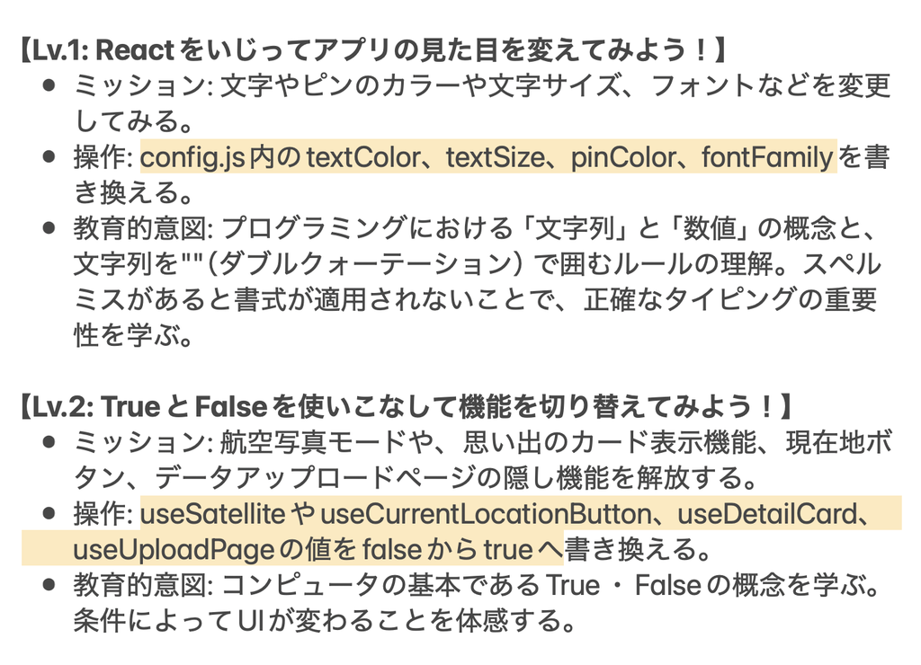

生徒に編集する部分がわかりやすいように、指導案のハイライト部分に従って編集ファイルを作成した。

**ノート**

指導案では`config.js`となっているが、**生徒が編集すべきファイルをわかりやすくするため**、ファイルを`lv1.js`、`lv2.js`と分けるようにした。

```
lv1.js
```

```javascript
/* 【Lv.1 ルール】
 *  ① 文字列を変更する時は、必ず ""（ダブルクォーテーション）で囲むこと。
 *  ② 数値を変更する時は、"" で囲んではならない。
 */

export const textColor = "white";         // 文字の色を指定する
export const pinColor = "red";            // ピンの色を指定する
export const textSize = 15;               // 文字の大きさを数値で指定する
export const fontFamily = "sans-serif";   // フォントの種類を指定する
```

```
lv2.js
```

```javascript
/* 【Lv.2 ルール】
 *  ① 機能を有効にする時はtrue、無効にする時はfalseと書く。
 *  ② "" で囲まない。
 */

export const useSatellite = false;       // マップのレイヤー切り替えボタンを表示する
export const useCurrentButton = false;   // 現在地ボタンを表示する
export const useDetailCard = false;     // 思い出の詳細カードを有効にする
export const useUploadPage = false;     // データ送信ページを有効にする
```

# 3 データ送信機能の設計

> 指導案からの抜粋（Lv.4）

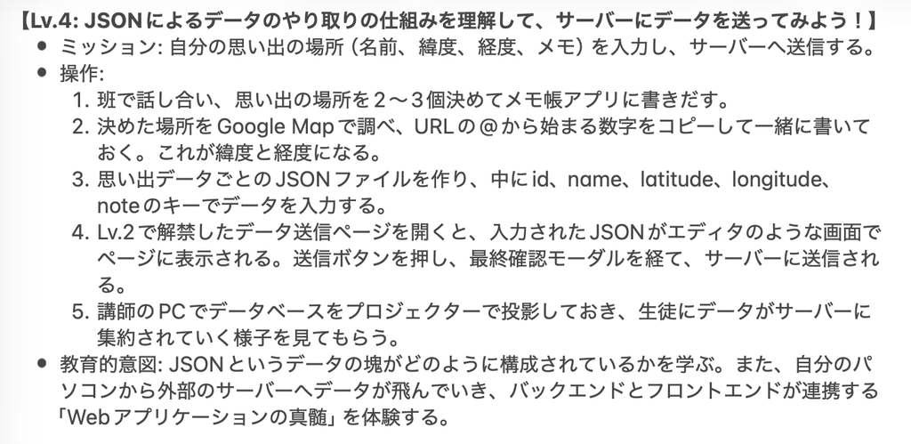

Lv.4で使うJSONファイルをサーバーに送信するモーダルを実装した。

```
StuUpload.jsx
```

```javascript
import React, { useState, useEffect, useMemo } from 'react';
import { Modal, Box, Button, Group, Title, Text, Select, Image, Code } from '@mantine/core';
import { IconSend, IconFileCode } from '@tabler/icons-react';
import hljs from 'highlight.js/lib/core';
import json from 'highlight.js/lib/languages/json';
import 'highlight.js/styles/vs2015.css';
import jsonErrorImage from '../assets/json_error.png';

hljs.registerLanguage('json', json);

// プロジェクト内の upload フォルダにある JSON ファイルをすべて自動取得
const seedModules = import.meta.glob('../upload/*.json', { eager: true });

export default function UploadPage({ opened, onClose }) {
  const [selectedFileIndex, setSelectedFileIndex] = useState(0);

  // ファイルリストを動的に生成（ファイルの追加・削除時に即座に反映）
  const files = useMemo(() => {
    const loadedFiles = Object.entries(seedModules).map(([path, mod]) => {
      const name = path.split('/').pop();
      const data = mod.default !== undefined ? mod.default : mod;
      return { name, content: JSON.stringify(data, null, 2), hasError: false };
    });

    if (loadedFiles.length === 0) {
      return [{ name: 'エラー', content: '', hasError: true, isNoFile: true }];
    }
    return loadedFiles;
  }, [seedModules]);

  // モーダルを開いた時に選択状態をリセット
  useEffect(() => {
    if (opened) {
      setSelectedFileIndex(0);
    }
  }, [opened]);

  // ファイルが削除されて選択中のインデックスが範囲外になったらリセット
  useEffect(() => {
    if (selectedFileIndex >= files.length) {
      setSelectedFileIndex(0);
    }
  }, [files.length, selectedFileIndex]);

  const currentFile = files.length > 0 ? files[selectedFileIndex] : { name: '未選択', content: '// 読み込み中...', hasError: false };

  // ファイルの内容が変更された時にハイライト処理を実行
  const highlightedCode = useMemo(() => {
    try {
      return hljs.highlight(currentFile.content, { language: 'json' }).value;
    } catch (error) {
      console.error("Syntax highlight error:", error);
      return currentFile.content;
    }
  }, [currentFile.content]);

  return (
    <Modal
      opened={opened}
      onClose={onClose}
      title={<Title order={3} c="white">データをサーバーへ送信</Title>}
      size="xl"
      yOffset={100}
      radius={20}
      overlayProps={{
        backgroundOpacity: 0.55,
        blur: 3,
      }}
      classNames={{
        content: 'glass-modal',
        header: 'glass-modal-header',
      }}
      styles={{
        header: { borderBottom: '1px solid rgba(255, 255, 255, 0.1)' },
        body: { padding: 0 },
        close: { color: 'white' }
      }}
    >

      {/* メイン部分（エディタ風プレビュー） */}
      <Box p="md" style={{ display: 'flex', flexDirection: 'column', gap: '16px', height: 'calc(100vh - 300px)' }}>
        <Group justify="space-between">
          <Group gap="xs">
            <IconFileCode size={20} color="#4dabf7" />
            {files.length > 1 ? (
              <Select
                data={files.map((f, i) => ({ value: String(i), label: f.name }))}
                value={String(selectedFileIndex)}
                onChange={(val) => setSelectedFileIndex(Number(val))}
                size="sm"
                variant="unstyled"
                styles={{ input: { color: '#C1C2C5', fontWeight: 700 } }}
                allowDeselect={false}
              />
            ) : (
              <Text c="dimmed" size="sm" fw={700}>{currentFile.name}</Text>
            )}
          </Group>
        </Group>

        <Box style={{
          flex: 1,
          backgroundColor: '#1e1e1e', // VSCodeのダークテーマ風の背景色
          borderRadius: '8px',
          border: '1px solid #373a40',
          overflow: 'auto',
          display: 'flex',
          minHeight: 0,
          alignItems: currentFile.hasError ? 'center' : 'stretch',
          justifyContent: currentFile.hasError ? 'center' : 'flex-start'
        }}>
          {currentFile.hasError ? (
            <Box p="md" style={{ textAlign: 'center' }}>
              <Image src={jsonErrorImage} alt="JSON Error" w="60%" maw={300} mx="auto" mb="md" />
              {currentFile.isNoFile ? (
                <Text c="red" fw={700}>
                  <Code c="white" bg="rgba(255, 255, 255, 0.15)">src/upload</Code> フォルダ内に送信できるファイルが見つかりません。
                </Text>
              ) : (
                <Text c="red" fw={700}>{currentFile.errorMessage || 'JSONファイルの形式が正しくありません。'}</Text>
              )}
            </Box>
          ) : (
            <>
              {/* 行番号 */}
              <Box style={{
                padding: '16px 8px',
                backgroundColor: '#1e1e1e',
                color: '#858585',
                textAlign: 'right',
                fontFamily: 'Menlo, Monaco, Consolas, monospace',
                fontSize: '14px',
                userSelect: 'none',
                borderRight: '1px solid #333',
                position: 'sticky',
                left: 0
              }}>
                {currentFile.content.split('\n').map((_, i) => (
                  <div key={i}>{i + 1}</div>
                ))}
              </Box>
              {/* コード表示部分 */}
              <pre style={{
                margin: 0,
                padding: '16px',
                color: '#d4d4d4',
                fontFamily: 'Menlo, Monaco, Consolas, monospace',
                fontSize: '14px',
                flex: 1,
                minWidth: 'max-content'
              }}>
                <code
                  className="hljs language-json"
                  style={{ background: 'transparent', padding: 0 }}
                  dangerouslySetInnerHTML={{ __html: highlightedCode }}
                />
              </pre>
            </>
          )}
        </Box>

        {/* フッター（ボタン類） */}
        <Group justify="flex-end">
          <Button
            color="cyan"
            leftSection={<IconSend size={18} />}
            onClick={() => alert('送信しました！')}
            disabled={currentFile.hasError}
          >
            送信
          </Button>
        </Group>
      </Box>
    </Modal>
  );
}
```

**1**

[Highlight.js](https://highlightjs.org/)と呼ばれる、コードをハイライトするJavaScriptライブラリのインポート。

**2**

VS Code風のダークテーマのインポート。

**3**

Viteの機能である `import.meta.glob` を使用し、指定したディレクトリ内のJSONファイルを一括で読み込んでいる。

**4**

選択されたファイルの内容から、Highlight.jsを使ってシンタックスハイライトされたHTML文字列を生成している。

**5**

生成したHTML文字列をReact上で描画するため、`dangerouslySetInnerHTML` を使用してDOMに直接反映している。

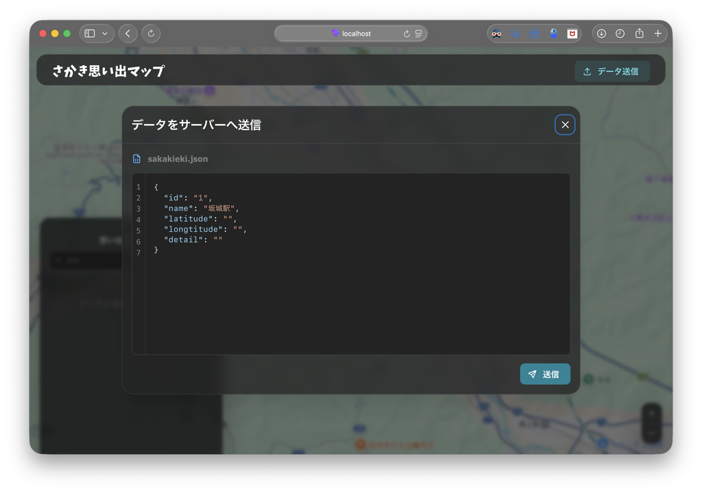

# 4 その他

## 4.1 オープニングアニメーションの導入

坂城町講座のポスター

[figure not shown]

少しでもネイティブアプリケーションのような体感に近づけ、子どもたちにワクワクしてもらいたいという思いから、ページを開いた時のオープニングアニメーションを導入した。文字はポスター（右図）のタイトル部分を使用した。

```
opening.jsx
```

```javascript
import React, { useState, useEffect } from 'react';
import { Box, Transition, Stack, Image } from '@mantine/core';
import titleImage from '../assets/title.png';

export default function Opening() {
  const [showSplash, setShowSplash] = useState(true);

  useEffect(() => {
    const timer = setTimeout(() => setShowSplash(false), 3000);
    return () => clearTimeout(timer);
  }, []);

  return (
    <Transition mounted={showSplash} transition="fade" duration={800} timingFunction="ease">
      {(styles) => (
        <Box
          style={{
            ...styles,
            position: 'fixed', top: 0, left: 0, right: 0, bottom: 0,
            zIndex: 99999,
            display: 'flex', alignItems: 'center', justifyContent: 'center',
            backgroundColor: 'rgba(0, 0, 0, 0.7)',
            backdropFilter: 'blur(15px)', WebkitBackdropFilter: 'blur(15px)',
          }}
        >
          <Stack align="center" gap="xl" w="100%">
            <Image src={titleImage} alt="さかき思い出マップ" w="60%" maw={400} className="title-zoom-animation" />
            <Box w="40%" maw={200} h={2} bg="rgba(255,255,255,0.2)" style={{ borderRadius: 2, overflow: 'hidden' }}>
              <Box h="100%" bg="white" className="progress-bar-animation" style={{ borderRadius: 2 }} />
            </Box>
          </Stack>
        </Box>
      )}
    </Transition>
  );
}
```

**1**

タイトル画像を`frontend/assets/title.png`から呼び出し。

**2**

3秒後に非表示にさせる。

**3**

0.8秒でフェードアウトさせるトランジションの書式設定。

**4**

背景のぼかし設定。

**5**

初期マップが白なので、不透明度70%の黒にしてアイコンを見やすくしている。

**6**

読み込みのプログレスバーのアニメーション。現状はダミーで、実際の読み込みは反映していない。

実際の動作

[video not shown]